# Tugas 4 MPDW

Arfiah Kania Sektiaruni

2023-09-21

# 1. MA(2)

## Membangiktkan model MA(2) dengan teta1 = 0.4 dan teta2 = 0.6 sebanyak 300 data (manual dan sengan arima.sim)

### White Noise

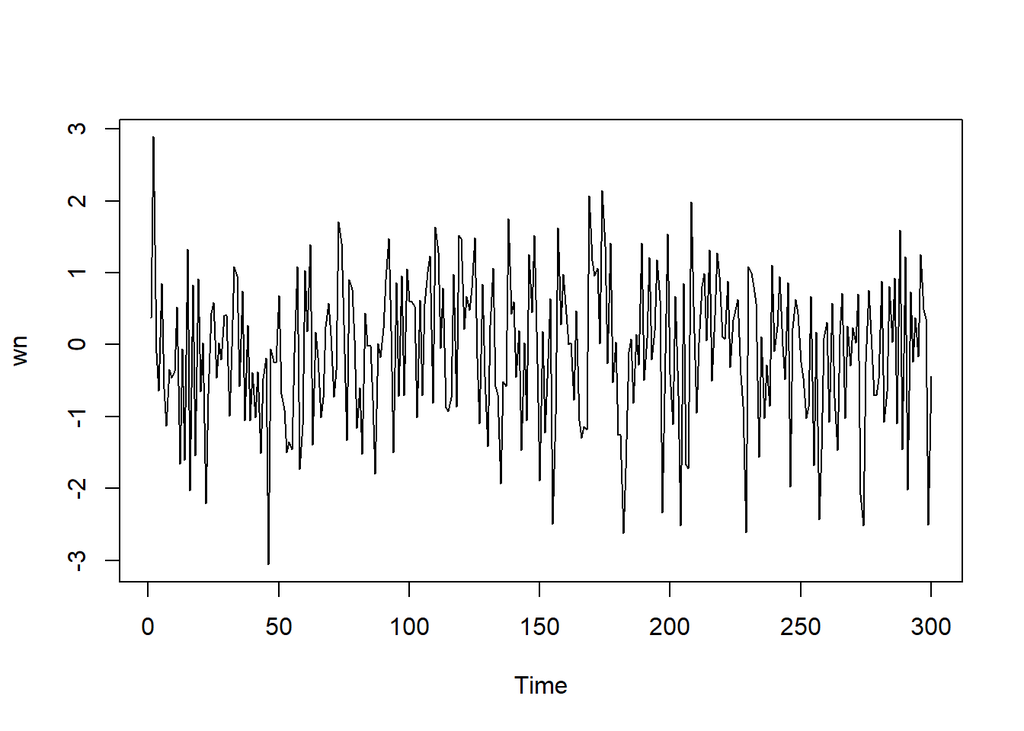

```r
wn <- rnorm(300)
ts.plot(wn)
```

```r
set.seed(023)
ma <- wn[c(1,2)]
ma
```

```
## [1] 0.3764867 2.8910833
```

Nilai-nilai selanjutnya dapat dicari melalui *loop*. Bentuk loop dapat dilihat dari rumus MA(2) yang hendak dibangkitkan:

$$y_t = e_t+0.4e_{t-1}+0.6e_{t-2}$$

```r
for(i in 3:300){
   ma[i] <- wn[i] + 0.4 * wn[i-1] + 0.6 * wn[i - 2]
}
ma
```

```
##   [1]  0.376486659  2.891083265  1.272939391  1.049329503  0.528455337
##   [6] -0.660323932 -0.867766297 -1.167038680 -1.276285900 -0.756024562
##  [11]  0.102562145 -1.673677061 -0.414898173 -2.635847349  0.643421450
##  [16] -2.470738795  0.807116406 -2.435734193  0.789594500 -1.211021488
##  [21]  0.309792804 -2.591360944 -1.551970879 -1.163496898  0.355554852
##  [26]  0.035818895  0.190514914 -0.481533808  0.335096222  0.439786757
##  [31] -0.586768006 -0.180757528  0.476906074  1.377054627  0.453350539
##  [36]  1.089294028 -1.102237824  0.290631381 -1.579802794 -0.654088463
##  [41] -1.806967638 -1.015694637 -2.271583889 -1.296964313 -1.282248111
##  [46] -3.416281679 -1.394294840 -2.096391138 -0.385318133  0.433415090
##  [51] -0.571718551 -0.781329468 -2.274489251 -2.495999349 -2.896649704
##  [56] -1.507575269  0.167025748 -1.362883701 -1.163388675 -0.453860137
##  [61] -0.082191647  2.081975145 -0.731771731  0.447599146 -0.949067464
##  [66] -0.981865970 -1.253537117 -0.652734853  0.230514709  0.508389876
##  [71] -0.335137033 -0.577333952  1.125884853  1.884175410  1.868599712
```

[output cut: 45 more lines]

```r
ma1 <- arima.sim(list(order=c(0,0,2), ma=c(0.4,0.6)), n=300)
ma1
```

```
## Time Series:
## Start = 1
## End = 300
## Frequency = 1
##   [1]  0.85532165  1.89788567  2.26192060  2.58216539  0.76287298  1.57246527
##   [7]  0.28626760  2.20547776  0.87586260 -0.01375221 -0.57632971 -0.26184638
##  [13] -1.19696950  0.11051650 -1.12674941 -0.46550299 -1.08834532  0.78946442
##  [19]  0.99363469  0.54488810  1.06324806 -1.19017065 -0.52414013 -0.91294433
##  [25] -0.83147786  1.03720732 -0.47097327  0.64811158 -0.88290527 -0.02312615
##  [31] -1.43931644 -1.64968475 -1.39008210 -0.65330070  1.25738044 -0.71337628
##  [37]  1.10849727 -0.22845302  1.65205692  1.88572609  2.10295151  0.19021663
##  [43] -1.04254226 -2.70692797 -1.28888624 -0.96271449  0.56002069 -0.03743293
##  [49]  1.47778120  0.12843854 -1.33627732 -0.24111047  0.30256183  0.05804925
##  [55] -0.17148592 -0.45876310  0.74344799  1.50725901  0.56653033  0.41060169
##  [61] -0.60597480 -0.10819194  1.62656718 -0.34906235 -0.31414295 -2.38467610
```

[output cut: 39 more lines]

## Buat plot time series, plot ACF, plot PACF, dan plot EACF. Identifikasi apakah data tersebut stasioner

### Plot Time Series

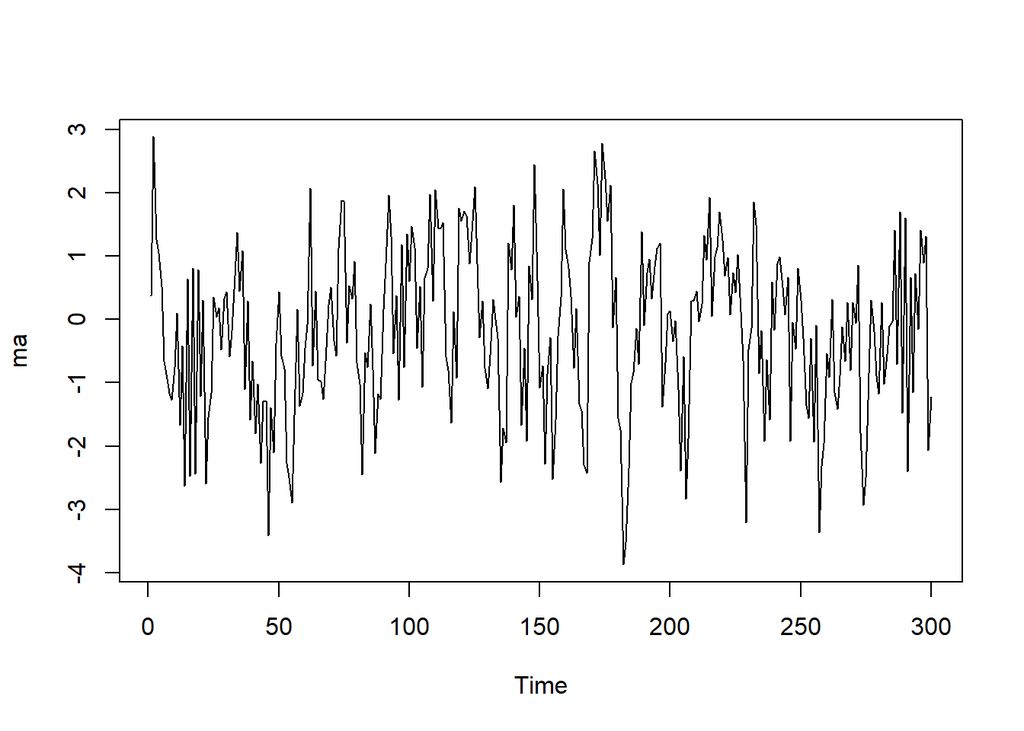

```r
ts.plot(ma)
```

Berdasarkan plot time series, terlihat bahwa data MA(2) yang dibangkitkan stasioner dalam rataan

### Plot ACF

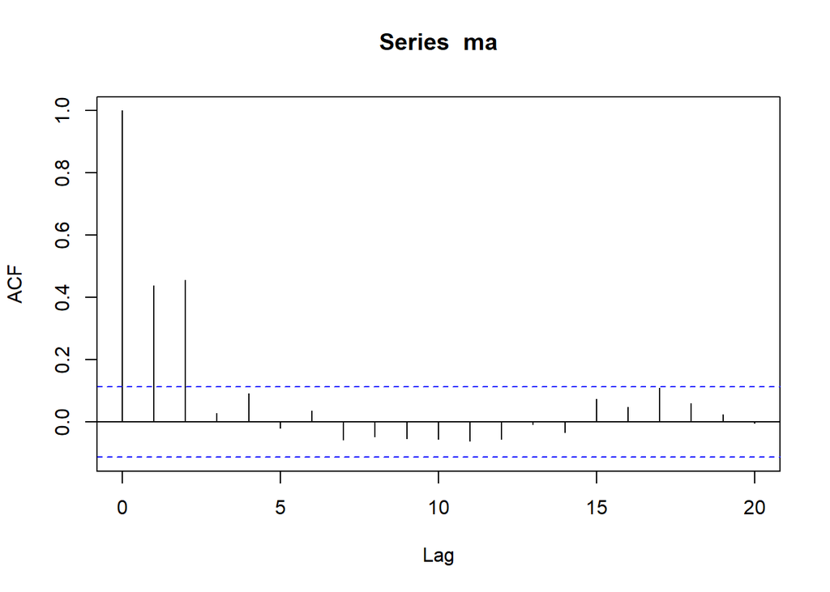

```r
acf(ma,lag.max = 20)
```

Berdasarkan plot AFC tersebut, terlihat bahwa plot ACF *cuts off* di lag pertama dan kedua

### Plot PACF

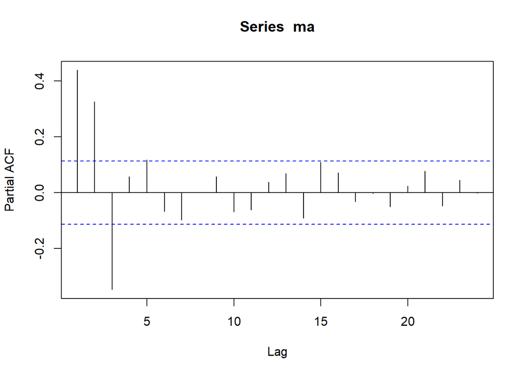

```r
pacf(ma)
```

Berdasarkan plot PACF tersebut, terlihat bahwa plot PACF cenderung *tails off* dan membentuk gelombang sinus

### Plot EACF

```r
TSA::eacf(ma)
```

```
## AR/MA
##   0 1 2 3 4 5 6 7 8 9 10 11 12 13
## 0 x x o o o o o o o o o  o  o  o
## 1 x x x o o o o o o o o  o  o  o
## 2 x x o o o o o o o o o  o  o  o
## 3 x x o o o o o o o o o  o  o  o
## 4 x x o o o x o o o o o  o  o  o
## 5 x x x o o o o o o o o  o  o  o
## 6 x x x o x o o o o o o  o  o  o
## 7 x x o x x o o o o o o  o  o  o
```

Dapat disimpulkan bahwa data tersebut stasioner

## Buat scatterplot dan korelasi antara $Y_t$ dengan $Y_{t-1}$, $Y_t$ dengan $Y_{t-2}$, serta $Y_t$ dengan $Y_{t-3}$

#### Korelasi antara $Y_t$ dengan $Y_{t-1}$

```r
#Yt
yt_ma <- ma[-1]
yt_ma
```

```
##   [1]  2.891083265  1.272939391  1.049329503  0.528455337 -0.660323932
##   [6] -0.867766297 -1.167038680 -1.276285900 -0.756024562  0.102562145
##  [11] -1.673677061 -0.414898173 -2.635847349  0.643421450 -2.470738795
##  [16]  0.807116406 -2.435734193  0.789594500 -1.211021488  0.309792804
##  [21] -2.591360944 -1.551970879 -1.163496898  0.355554852  0.035818895
##  [26]  0.190514914 -0.481533808  0.335096222  0.439786757 -0.586768006
##  [31] -0.180757528  0.476906074  1.377054627  0.453350539  1.089294028
##  [36] -1.102237824  0.290631381 -1.579802794 -0.654088463 -1.806967638
##  [41] -1.015694637 -2.271583889 -1.296964313 -1.282248111 -3.416281679
##  [46] -1.394294840 -2.096391138 -0.385318133  0.433415090 -0.571718551
##  [51] -0.781329468 -2.274489251 -2.495999349 -2.896649704 -1.507575269
##  [56]  0.167025748 -1.362883701 -1.163388675 -0.453860137 -0.082191647
##  [61]  2.081975145 -0.731771731  0.447599146 -0.949067464 -0.981865970
##  [66] -1.253537117 -0.652734853  0.230514709  0.508389876 -0.335137033
##  [71] -0.577333952  1.125884853  1.884175410  1.868599712 -0.373986078
```

[output cut: 45 more lines]

```r
#Yt-1
yt_1_ma <- ma[-300]
yt_1_ma
```

```
##   [1]  0.376486659  2.891083265  1.272939391  1.049329503  0.528455337
##   [6] -0.660323932 -0.867766297 -1.167038680 -1.276285900 -0.756024562
##  [11]  0.102562145 -1.673677061 -0.414898173 -2.635847349  0.643421450
##  [16] -2.470738795  0.807116406 -2.435734193  0.789594500 -1.211021488
##  [21]  0.309792804 -2.591360944 -1.551970879 -1.163496898  0.355554852
##  [26]  0.035818895  0.190514914 -0.481533808  0.335096222  0.439786757
##  [31] -0.586768006 -0.180757528  0.476906074  1.377054627  0.453350539
##  [36]  1.089294028 -1.102237824  0.290631381 -1.579802794 -0.654088463
##  [41] -1.806967638 -1.015694637 -2.271583889 -1.296964313 -1.282248111
##  [46] -3.416281679 -1.394294840 -2.096391138 -0.385318133  0.433415090
##  [51] -0.571718551 -0.781329468 -2.274489251 -2.495999349 -2.896649704
##  [56] -1.507575269  0.167025748 -1.362883701 -1.163388675 -0.453860137
##  [61] -0.082191647  2.081975145 -0.731771731  0.447599146 -0.949067464
##  [66] -0.981865970 -1.253537117 -0.652734853  0.230514709  0.508389876
##  [71] -0.335137033 -0.577333952  1.125884853  1.884175410  1.868599712
```

[output cut: 45 more lines]

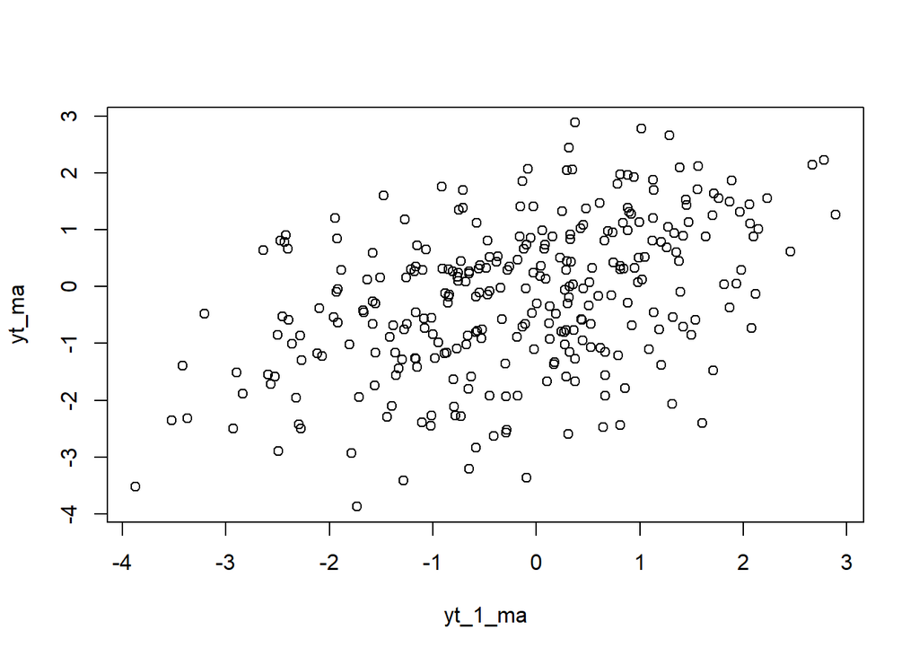

```r
plot(y=yt_ma,x=yt_1_ma)
```

```r
cor(yt_ma,yt_1_ma)
```

```
## [1] 0.4385996
```

#### Korelasi antara $Y_t$ dengan $Y_{t-2}$

```r
#Yt
yt_ma2 <- ma[-c(1,2)]
yt_ma2
```

```
##   [1]  1.272939391  1.049329503  0.528455337 -0.660323932 -0.867766297
##   [6] -1.167038680 -1.276285900 -0.756024562  0.102562145 -1.673677061
##  [11] -0.414898173 -2.635847349  0.643421450 -2.470738795  0.807116406
##  [16] -2.435734193  0.789594500 -1.211021488  0.309792804 -2.591360944
##  [21] -1.551970879 -1.163496898  0.355554852  0.035818895  0.190514914
##  [26] -0.481533808  0.335096222  0.439786757 -0.586768006 -0.180757528
##  [31]  0.476906074  1.377054627  0.453350539  1.089294028 -1.102237824
##  [36]  0.290631381 -1.579802794 -0.654088463 -1.806967638 -1.015694637
##  [41] -2.271583889 -1.296964313 -1.282248111 -3.416281679 -1.394294840
##  [46] -2.096391138 -0.385318133  0.433415090 -0.571718551 -0.781329468
##  [51] -2.274489251 -2.495999349 -2.896649704 -1.507575269  0.167025748
##  [56] -1.362883701 -1.163388675 -0.453860137 -0.082191647  2.081975145
##  [61] -0.731771731  0.447599146 -0.949067464 -0.981865970 -1.253537117
##  [66] -0.652734853  0.230514709  0.508389876 -0.335137033 -0.577333952
##  [71]  1.125884853  1.884175410  1.868599712 -0.373986078  0.540078189
```

[output cut: 45 more lines]

```r
#Yt-2
yt_2_ma <- ma[-c(299,300)]
yt_2_ma
```

```
##   [1]  0.376486659  2.891083265  1.272939391  1.049329503  0.528455337
##   [6] -0.660323932 -0.867766297 -1.167038680 -1.276285900 -0.756024562
##  [11]  0.102562145 -1.673677061 -0.414898173 -2.635847349  0.643421450
##  [16] -2.470738795  0.807116406 -2.435734193  0.789594500 -1.211021488
##  [21]  0.309792804 -2.591360944 -1.551970879 -1.163496898  0.355554852
##  [26]  0.035818895  0.190514914 -0.481533808  0.335096222  0.439786757
##  [31] -0.586768006 -0.180757528  0.476906074  1.377054627  0.453350539
##  [36]  1.089294028 -1.102237824  0.290631381 -1.579802794 -0.654088463
##  [41] -1.806967638 -1.015694637 -2.271583889 -1.296964313 -1.282248111
##  [46] -3.416281679 -1.394294840 -2.096391138 -0.385318133  0.433415090
##  [51] -0.571718551 -0.781329468 -2.274489251 -2.495999349 -2.896649704
##  [56] -1.507575269  0.167025748 -1.362883701 -1.163388675 -0.453860137
##  [61] -0.082191647  2.081975145 -0.731771731  0.447599146 -0.949067464
##  [66] -0.981865970 -1.253537117 -0.652734853  0.230514709  0.508389876
##  [71] -0.335137033 -0.577333952  1.125884853  1.884175410  1.868599712
```

[output cut: 45 more lines]

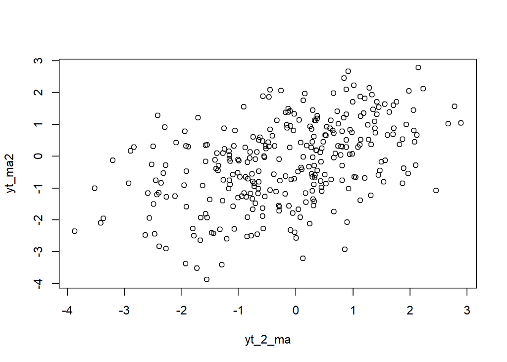

```r
plot(y=yt_ma2,x=yt_2_ma)
```

Berdasarkan scatterplot tersebut, terlihat bahwa terdapat hubungan yang positif antara $Y_t$ dengan $Y_{t-2}$.

```r
cor(yt_ma2,yt_2_ma)
```

```
## [1] 0.4618698
```

#### Korelasi antara $Y_t$ dengan $Y_{t-3}$

```r
#Yt
yt_ma3 <- ma[-c(1,2,3)]
yt_ma3
```

```
##   [1]  1.049329503  0.528455337 -0.660323932 -0.867766297 -1.167038680
##   [6] -1.276285900 -0.756024562  0.102562145 -1.673677061 -0.414898173
##  [11] -2.635847349  0.643421450 -2.470738795  0.807116406 -2.435734193
##  [16]  0.789594500 -1.211021488  0.309792804 -2.591360944 -1.551970879
##  [21] -1.163496898  0.355554852  0.035818895  0.190514914 -0.481533808
##  [26]  0.335096222  0.439786757 -0.586768006 -0.180757528  0.476906074
##  [31]  1.377054627  0.453350539  1.089294028 -1.102237824  0.290631381
##  [36] -1.579802794 -0.654088463 -1.806967638 -1.015694637 -2.271583889
##  [41] -1.296964313 -1.282248111 -3.416281679 -1.394294840 -2.096391138
##  [46] -0.385318133  0.433415090 -0.571718551 -0.781329468 -2.274489251
##  [51] -2.495999349 -2.896649704 -1.507575269  0.167025748 -1.362883701
##  [56] -1.163388675 -0.453860137 -0.082191647  2.081975145 -0.731771731
##  [61]  0.447599146 -0.949067464 -0.981865970 -1.253537117 -0.652734853
##  [66]  0.230514709  0.508389876 -0.335137033 -0.577333952  1.125884853
##  [71]  1.884175410  1.868599712 -0.373986078  0.540078189  0.326100544
```

[output cut: 45 more lines]

```r
#Yt-3
yt_3_ma <- ma[-c(298,299,300)]
yt_3_ma
```

```
##   [1]  0.376486659  2.891083265  1.272939391  1.049329503  0.528455337
##   [6] -0.660323932 -0.867766297 -1.167038680 -1.276285900 -0.756024562
##  [11]  0.102562145 -1.673677061 -0.414898173 -2.635847349  0.643421450
##  [16] -2.470738795  0.807116406 -2.435734193  0.789594500 -1.211021488
##  [21]  0.309792804 -2.591360944 -1.551970879 -1.163496898  0.355554852
##  [26]  0.035818895  0.190514914 -0.481533808  0.335096222  0.439786757
##  [31] -0.586768006 -0.180757528  0.476906074  1.377054627  0.453350539
##  [36]  1.089294028 -1.102237824  0.290631381 -1.579802794 -0.654088463
##  [41] -1.806967638 -1.015694637 -2.271583889 -1.296964313 -1.282248111
##  [46] -3.416281679 -1.394294840 -2.096391138 -0.385318133  0.433415090
##  [51] -0.571718551 -0.781329468 -2.274489251 -2.495999349 -2.896649704
##  [56] -1.507575269  0.167025748 -1.362883701 -1.163388675 -0.453860137
##  [61] -0.082191647  2.081975145 -0.731771731  0.447599146 -0.949067464
##  [66] -0.981865970 -1.253537117 -0.652734853  0.230514709  0.508389876
##  [71] -0.335137033 -0.577333952  1.125884853  1.884175410  1.868599712
```

[output cut: 45 more lines]

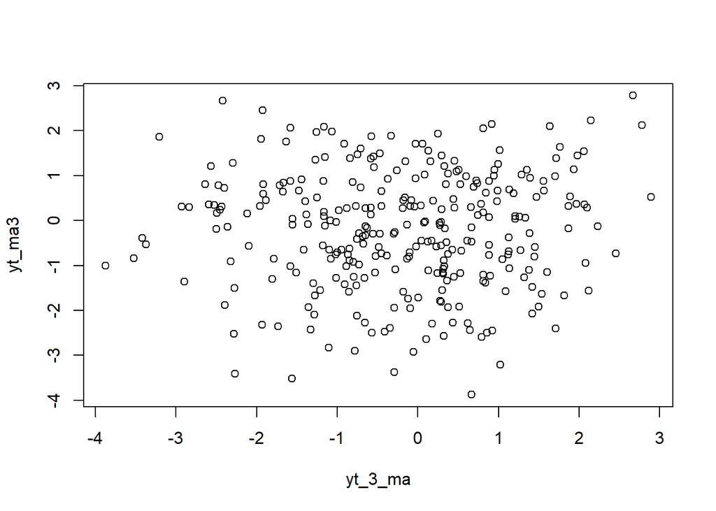

```r
plot(y=yt_ma3,x=yt_3_ma)
```

```r
cor(yt_ma3,yt_3_ma)
```

```
## [1] 0.02760745
```

Korelasi antara $Y_t$ dengan $Y_{t-3}$ hasil simulasi mendekati teori yang ada yaitu 0.

# 2. AR(2)

## Bangkitkan model AR(2) dengan 𝜙1 = 0.5 dan 𝜙2 = 0.2 sebanyak300 data (Manual dan dengan arima.sim)

### Pembangkitan Proses AR

Akan dicoba membangkitkan proses AR paling sederhana, yaitu AR(2) dengan $\phi_1 = 0.5$ dan $\phi_2 = 0.2$ sebanyak 300 observasi dan $c=0$.

```r
set.seed(023)
```

Nilai-nilai selanjutnya dapat dicari melalui *loop*. Bentuk loop dapat dilihat dari rumus AR(2) yang hendak dibangkitkan:

$$Y_t = e_t+0.5Y_{t-1}+0.2Y_{t-2}$$

```r
n<-length(wn)
n
```

```
## [1] 300
```

```r
ar <- c(1:n)
for (i in 3:n) {ar[i]<-wn[i]+0.5*ar[i-1]+0.2*ar[i-2]}
ar
```

```
##   [1]  1.000000000  2.000000000  1.090614090  0.303740953  1.220706614
##   [6]  0.055431893 -0.860069177 -0.763814548 -1.013104606 -1.024746573
##  [11] -0.190749421 -1.964440185 -1.084168557 -2.546830537 -0.163805092
##  [16] -2.625470071 -0.520565413 -2.330562320 -0.356683887 -1.293448679
##  [21] -0.696296818 -2.817508246 -2.228774904 -1.242679372 -0.477166856
##  [26] -0.948397369 -0.548562602 -0.677155524 -0.040557833  0.248900606
##  [31] -0.876912990 -0.414899587  0.700514003  1.226727082  0.173029045
##  [36]  1.077658886 -0.478859773  0.240171913 -1.029739786 -0.857744472
##  [41] -1.652991974 -1.371925429 -2.527689711 -2.006414485 -1.697042317
##  [46] -4.309856156 -2.551632262 -2.375228952 -1.953904993 -0.773732617
##  [51] -1.467093687 -1.800803685 -2.689637876 -3.055145914 -3.524593363
##  [56] -2.487164257 -0.860483997 -2.657462237 -2.625111721 -0.810322492
##  [61] -0.751295282  0.852472193 -1.119201409 -0.217546339 -0.513197817
##  [66] -1.312676356 -1.499136967 -0.761234010 -0.106182052 -0.077174738
##  [71] -0.790783457 -0.772674611  1.164705837  1.845422234  1.431690401
```

[output cut: 45 more lines]

Selain menggunakan cara di atas, pembangkitan proses AR dapat dilakukan dengan fungsi `arima.sim()` sebagai berikut.

```r
ar1 <- arima.sim(list(order=c(2,0,0), ar=c(0.5,0.2)), n=300)
ar1
```

```
## Time Series:
## Start = 1
## End = 300
## Frequency = 1
##   [1] -0.473844877 -0.884413028  0.705892023 -0.484519445  0.065542897
##   [6] -0.617337681 -0.197378846 -1.368822819 -1.973814435 -1.462783464
##  [11] -0.948654294  0.540763481 -1.262284523  0.338093474  0.149464836
##  [16]  1.184608206  1.951295324  2.158527257  0.483897189 -0.542212787
##  [21] -1.803532892 -0.917892765 -0.841770384 -0.090985832 -0.443400631
##  [26]  1.021618421  0.183693445 -1.701642201 -0.113006453  0.823987347
##  [31] -0.461531550 -0.629576062 -0.129859974  0.779873697  1.316595687
##  [36]  0.417319239  0.469783285 -0.048569116  0.109567287  1.875833692
##  [41] -0.145474710 -0.668049887 -1.696421266 -0.234814007 -1.670069798
##  [46] -0.155990192 -0.841933837 -0.584740670  0.570738668  0.175392594
##  [51]  0.635253070  1.640074368 -1.471176476 -1.780224758 -1.663747649
```

[output cut: 49 more lines]

## Buat plot time series, plot ACF, plot PACF dan plot EACF. Idenifikasi apakah data tersebut stasioner

### Plot Time Series

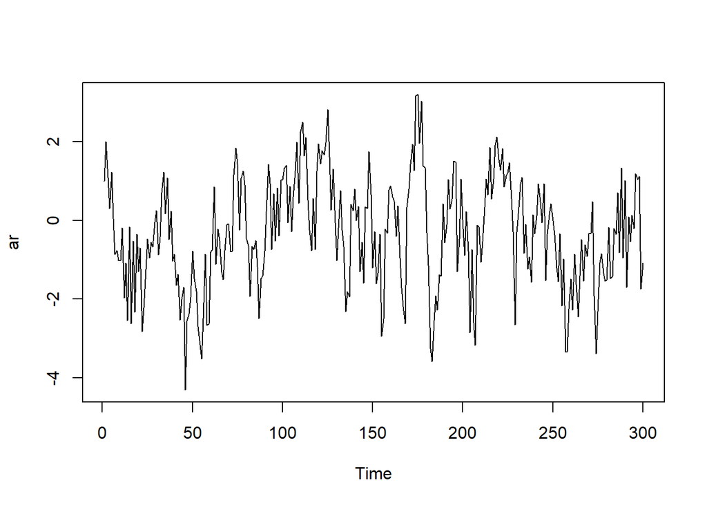

```r
ts.plot(ar)
```

Berdasarkan plot time series tersebut terlihat bahwa data cenderung stasioner pada rataan

### Plot ACF

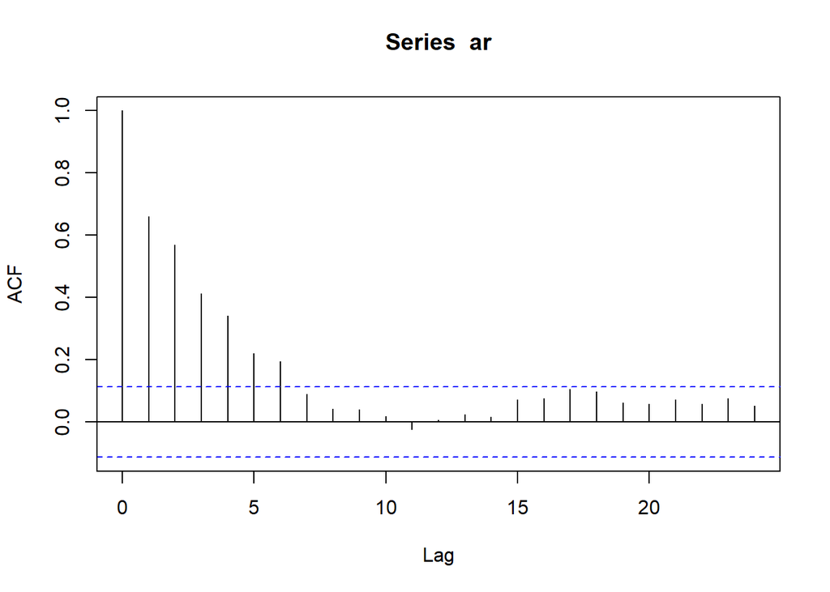

```r
acf(ar)
```

### Plot PACF

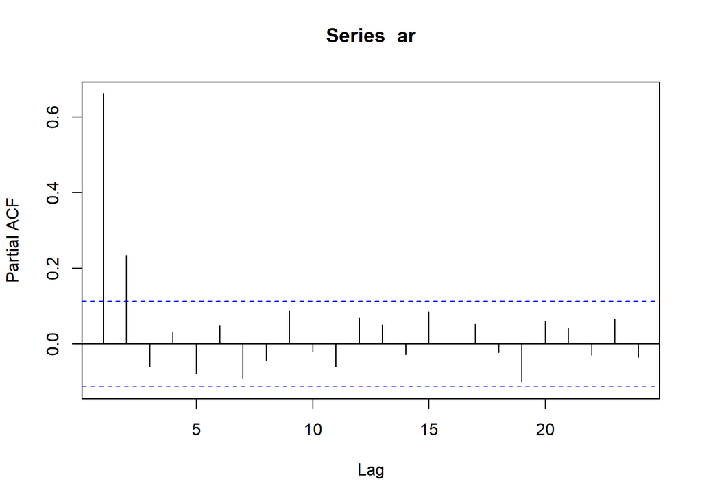

```r
pacf(ar)
```

### Plot EACF

```r
TSA::eacf(ar)
```

```
## AR/MA
##   0 1 2 3 4 5 6 7 8 9 10 11 12 13
## 0 x x x x x x o o o o o  o  o  o
## 1 x x o x x x o o o o o  o  o  o
## 2 x o o o o x o o o o o  o  o  o
## 3 x o x o o x o o o o o  o  o  o
## 4 x x o o o x o o o o o  o  o  o
## 5 x x o o o o o o o o o  o  o  o
## 6 x x x x x o o o o o o  o  o  o
## 7 x x x o o o o o o o o  o  o  o
```

Dapat disimpulkan bahwa data tersebut stasioner

## Buat scatterplot dan korelasi antara $Y_t$ dengan $Y_{t-1}$, $Y_t$ dengan $Y_{t-2}$, serta $Y_t$ dengan $Y_{t-3}$

### Korelasi antara $Y_t$ dengan $Y_{t-1}$

```r
#Yt
yt_ar <- ar[-1]
yt_ar
```

```
##   [1]  2.000000000  1.090614090  0.303740953  1.220706614  0.055431893
##   [6] -0.860069177 -0.763814548 -1.013104606 -1.024746573 -0.190749421
##  [11] -1.964440185 -1.084168557 -2.546830537 -0.163805092 -2.625470071
##  [16] -0.520565413 -2.330562320 -0.356683887 -1.293448679 -0.696296818
##  [21] -2.817508246 -2.228774904 -1.242679372 -0.477166856 -0.948397369
##  [26] -0.548562602 -0.677155524 -0.040557833  0.248900606 -0.876912990
##  [31] -0.414899587  0.700514003  1.226727082  0.173029045  1.077658886
##  [36] -0.478859773  0.240171913 -1.029739786 -0.857744472 -1.652991974
##  [41] -1.371925429 -2.527689711 -2.006414485 -1.697042317 -4.309856156
##  [46] -2.551632262 -2.375228952 -1.953904993 -0.773732617 -1.467093687
##  [51] -1.800803685 -2.689637876 -3.055145914 -3.524593363 -2.487164257
##  [56] -0.860483997 -2.657462237 -2.625111721 -0.810322492 -0.751295282
##  [61]  0.852472193 -1.119201409 -0.217546339 -0.513197817 -1.312676356
##  [66] -1.499136967 -0.761234010 -0.106182052 -0.077174738 -0.790783457
##  [71] -0.772674611  1.164705837  1.845422234  1.431690401 -0.250034220
```

[output cut: 45 more lines]

```r
#Yt-1
yt_1_ar <- ar[-300]
yt_1_ar
```

```
##   [1]  1.000000000  2.000000000  1.090614090  0.303740953  1.220706614
##   [6]  0.055431893 -0.860069177 -0.763814548 -1.013104606 -1.024746573
##  [11] -0.190749421 -1.964440185 -1.084168557 -2.546830537 -0.163805092
##  [16] -2.625470071 -0.520565413 -2.330562320 -0.356683887 -1.293448679
##  [21] -0.696296818 -2.817508246 -2.228774904 -1.242679372 -0.477166856
##  [26] -0.948397369 -0.548562602 -0.677155524 -0.040557833  0.248900606
##  [31] -0.876912990 -0.414899587  0.700514003  1.226727082  0.173029045
##  [36]  1.077658886 -0.478859773  0.240171913 -1.029739786 -0.857744472
##  [41] -1.652991974 -1.371925429 -2.527689711 -2.006414485 -1.697042317
##  [46] -4.309856156 -2.551632262 -2.375228952 -1.953904993 -0.773732617
##  [51] -1.467093687 -1.800803685 -2.689637876 -3.055145914 -3.524593363
##  [56] -2.487164257 -0.860483997 -2.657462237 -2.625111721 -0.810322492
##  [61] -0.751295282  0.852472193 -1.119201409 -0.217546339 -0.513197817
##  [66] -1.312676356 -1.499136967 -0.761234010 -0.106182052 -0.077174738
##  [71] -0.790783457 -0.772674611  1.164705837  1.845422234  1.431690401
```

[output cut: 45 more lines]

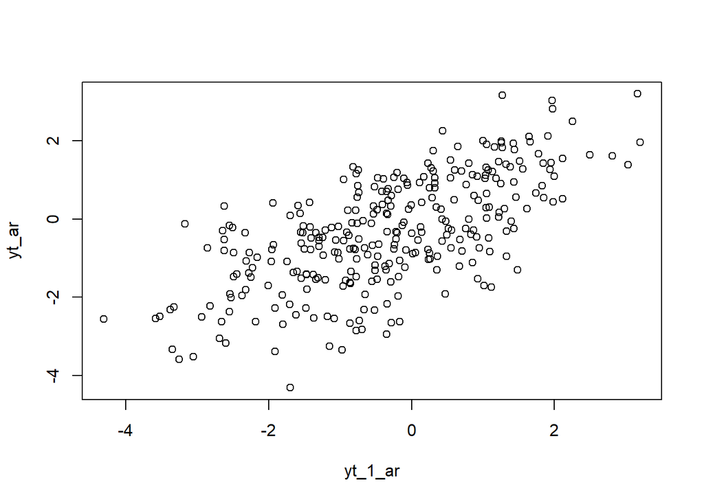

```r
plot(y=yt_ar,x=yt_1_ar)
```

Berdasarkan scatterplot tersebut, terlihat bahwa terdapat hubungan positif antara $Y_t$ dengan $Y_{t-1}$. Hal ini sesuai dengan teori yang ada

```r
cor(yt_ar,yt_1_ar)
```

```
## [1] 0.6621678
```

Korelasi antara $Y_t$ dengan $Y_{t-1}$ dari hasil simulasi mendekati perhitungan teoritis yaitu

$$\rho_1=\frac{\phi_{1}}{1-\phi_{2}}=\frac{0.5}{1-0.2}=0.625$$

### Korelasi antara $Y_t$ dengan $Y_{t-2}$

```r
#Yt
yt_ar2 <- ar[-c(1,2)]
yt_ar2
```

```
##   [1]  1.090614090  0.303740953  1.220706614  0.055431893 -0.860069177
##   [6] -0.763814548 -1.013104606 -1.024746573 -0.190749421 -1.964440185
##  [11] -1.084168557 -2.546830537 -0.163805092 -2.625470071 -0.520565413
##  [16] -2.330562320 -0.356683887 -1.293448679 -0.696296818 -2.817508246
##  [21] -2.228774904 -1.242679372 -0.477166856 -0.948397369 -0.548562602
##  [26] -0.677155524 -0.040557833  0.248900606 -0.876912990 -0.414899587
##  [31]  0.700514003  1.226727082  0.173029045  1.077658886 -0.478859773
##  [36]  0.240171913 -1.029739786 -0.857744472 -1.652991974 -1.371925429
##  [41] -2.527689711 -2.006414485 -1.697042317 -4.309856156 -2.551632262
##  [46] -2.375228952 -1.953904993 -0.773732617 -1.467093687 -1.800803685
##  [51] -2.689637876 -3.055145914 -3.524593363 -2.487164257 -0.860483997
##  [56] -2.657462237 -2.625111721 -0.810322492 -0.751295282  0.852472193
##  [61] -1.119201409 -0.217546339 -0.513197817 -1.312676356 -1.499136967
##  [66] -0.761234010 -0.106182052 -0.077174738 -0.790783457 -0.772674611
##  [71]  1.164705837  1.845422234  1.431690401 -0.250034220  1.069761837
```

[output cut: 45 more lines]

```r
#Yt-2
yt_2_ar <- ar[-c(299,300)]
yt_2_ar
```

```
##   [1]  1.000000000  2.000000000  1.090614090  0.303740953  1.220706614
##   [6]  0.055431893 -0.860069177 -0.763814548 -1.013104606 -1.024746573
##  [11] -0.190749421 -1.964440185 -1.084168557 -2.546830537 -0.163805092
##  [16] -2.625470071 -0.520565413 -2.330562320 -0.356683887 -1.293448679
##  [21] -0.696296818 -2.817508246 -2.228774904 -1.242679372 -0.477166856
##  [26] -0.948397369 -0.548562602 -0.677155524 -0.040557833  0.248900606
##  [31] -0.876912990 -0.414899587  0.700514003  1.226727082  0.173029045
##  [36]  1.077658886 -0.478859773  0.240171913 -1.029739786 -0.857744472
##  [41] -1.652991974 -1.371925429 -2.527689711 -2.006414485 -1.697042317
##  [46] -4.309856156 -2.551632262 -2.375228952 -1.953904993 -0.773732617
##  [51] -1.467093687 -1.800803685 -2.689637876 -3.055145914 -3.524593363
##  [56] -2.487164257 -0.860483997 -2.657462237 -2.625111721 -0.810322492
##  [61] -0.751295282  0.852472193 -1.119201409 -0.217546339 -0.513197817
##  [66] -1.312676356 -1.499136967 -0.761234010 -0.106182052 -0.077174738
##  [71] -0.790783457 -0.772674611  1.164705837  1.845422234  1.431690401
```

[output cut: 45 more lines]

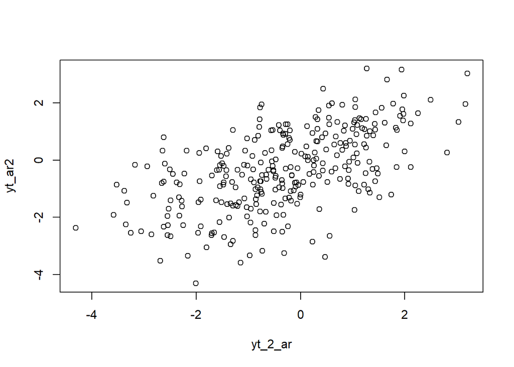

```r
plot(y=yt_ar2,x=yt_2_ar)
```

Berdasarkan scatterplot tersebut, terlihat bahwa terdapat hubungan positif yang lemah antara $Y_t$ dengan $Y_{t-2}$. Hal ini sesuai dengan teori yang ada

```r
cor(yt_ar2,yt_2_ar)
```

```
## [1] 0.5738651
```

Korelasi antara $Y_t$ dengan $Y_{t-2}$ dari hasil simulasi mendekati perhitungan teoritis yaitu

$$\rho_2=\frac{\phi_{2}(1-\phi_{2})+\phi_{1}^2}{1-\phi_{2}}=\frac{0.2(1-0.2)+0.5^2}{1-0.2}=0.512$$

### Korelasi antara $Y_t$ dengan $Y_{t-3}$

```r
#Yt
yt_ar3 <- ar[-c(1,2,3)]
yt_ar3
```

```
##   [1]  0.303740953  1.220706614  0.055431893 -0.860069177 -0.763814548
##   [6] -1.013104606 -1.024746573 -0.190749421 -1.964440185 -1.084168557
##  [11] -2.546830537 -0.163805092 -2.625470071 -0.520565413 -2.330562320
##  [16] -0.356683887 -1.293448679 -0.696296818 -2.817508246 -2.228774904
##  [21] -1.242679372 -0.477166856 -0.948397369 -0.548562602 -0.677155524
##  [26] -0.040557833  0.248900606 -0.876912990 -0.414899587  0.700514003
##  [31]  1.226727082  0.173029045  1.077658886 -0.478859773  0.240171913
##  [36] -1.029739786 -0.857744472 -1.652991974 -1.371925429 -2.527689711
##  [41] -2.006414485 -1.697042317 -4.309856156 -2.551632262 -2.375228952
##  [46] -1.953904993 -0.773732617 -1.467093687 -1.800803685 -2.689637876
##  [51] -3.055145914 -3.524593363 -2.487164257 -0.860483997 -2.657462237
##  [56] -2.625111721 -0.810322492 -0.751295282  0.852472193 -1.119201409
##  [61] -0.217546339 -0.513197817 -1.312676356 -1.499136967 -0.761234010
##  [66] -0.106182052 -0.077174738 -0.790783457 -0.772674611  1.164705837
##  [71]  1.845422234  1.431690401 -0.250034220  1.069761837  1.248576592
```

[output cut: 45 more lines]

```r
#Yt-3
yt_3_ar <- ar[-c(298,299,300)]
yt_3_ar
```

```
##   [1]  1.000000000  2.000000000  1.090614090  0.303740953  1.220706614
##   [6]  0.055431893 -0.860069177 -0.763814548 -1.013104606 -1.024746573
##  [11] -0.190749421 -1.964440185 -1.084168557 -2.546830537 -0.163805092
##  [16] -2.625470071 -0.520565413 -2.330562320 -0.356683887 -1.293448679
##  [21] -0.696296818 -2.817508246 -2.228774904 -1.242679372 -0.477166856
##  [26] -0.948397369 -0.548562602 -0.677155524 -0.040557833  0.248900606
##  [31] -0.876912990 -0.414899587  0.700514003  1.226727082  0.173029045
##  [36]  1.077658886 -0.478859773  0.240171913 -1.029739786 -0.857744472
##  [41] -1.652991974 -1.371925429 -2.527689711 -2.006414485 -1.697042317
##  [46] -4.309856156 -2.551632262 -2.375228952 -1.953904993 -0.773732617
##  [51] -1.467093687 -1.800803685 -2.689637876 -3.055145914 -3.524593363
##  [56] -2.487164257 -0.860483997 -2.657462237 -2.625111721 -0.810322492
##  [61] -0.751295282  0.852472193 -1.119201409 -0.217546339 -0.513197817
##  [66] -1.312676356 -1.499136967 -0.761234010 -0.106182052 -0.077174738
##  [71] -0.790783457 -0.772674611  1.164705837  1.845422234  1.431690401
```

[output cut: 45 more lines]

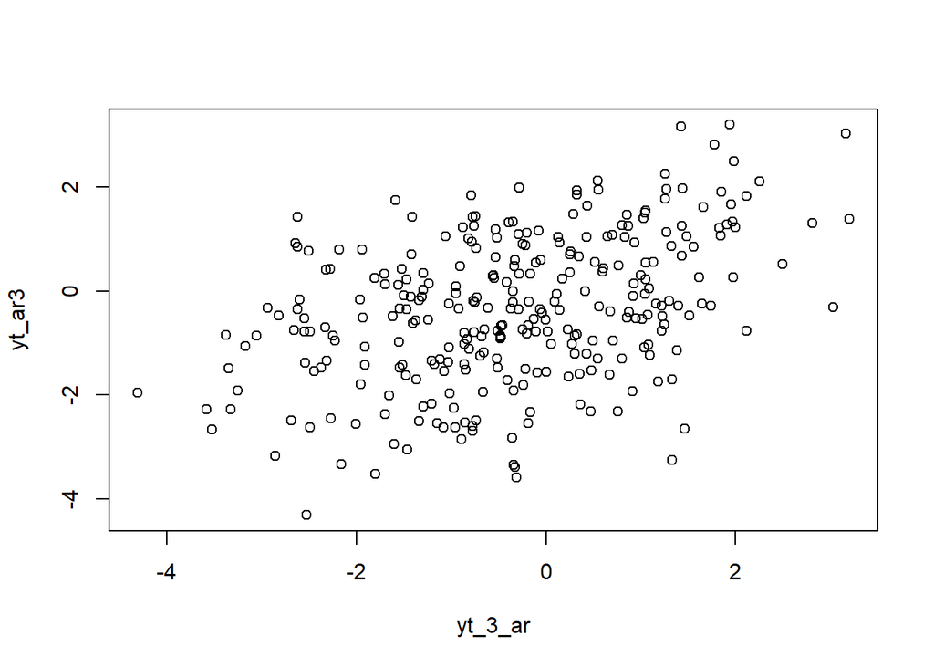

```r
plot(y=yt_ar3,x=yt_3_ar)
```

Berdasarkan scatterplot tersebut, terlihat bahwa terdapat hubungan positif yang lemah antara $Y_t$ dengan $Y_{t-3}$. Hal ini sesuai dengan teori yang ada

```r
cor(yt_ar3,yt_3_ar)
```

```
## [1] 0.4163187
```

# 2. ARMA(2,2)

### Pembangkitan proses ARMA

```r
set.seed(023)
n = length(wn)
phi1 = 0.5
phi2 = 0.2

theta1 = 0.4
theta2 = 0.6

y.arma=c(1:n)
for (i in 3:n){y.arma[i] = phi1*y.arma[i-1] + phi2*y.arma[i-2] + theta1*wn[i-1] + theta2*wn[i-2] + wn[i]}
head(y.arma)
```

```
## [1] 1.000000 2.000000 2.472939 2.685799 2.365943 1.059807
```

Pembangkitan ARMA(p,q) juga dapat dilakukan dengan fungsi `arima.sim` sebagai berikut.

```r
arma22 <- arima.sim(list(order=c(2,0,2), ar = c(0.5,0.2), ma = c(0.4,0.6)), n=300)
arma22
```

```
## Time Series:
## Start = 1
## End = 300
## Frequency = 1
##   [1]  0.06795477 -0.73270762  0.29534872 -0.88177243 -0.40494262 -1.81814223
##   [7] -2.63974439 -3.07358274 -2.71804095 -0.71635658 -1.61516276  0.15764457
##  [13] -0.47266329  1.44725419  2.51482053  3.64981261  2.51808704  0.94646378
##  [19] -1.73007867 -1.96463282 -2.29104663 -0.97842919 -0.98485685  0.78966693
##  [25]  0.32630064 -1.01519362 -0.68344715 -0.24220047 -0.19974042 -0.31979622
##  [31] -0.65860929  0.35018410  1.55062920  1.41188175  1.42666841  0.38973575
##  [37]  0.37200962  1.89051914  0.67059914  0.39926045 -2.05092604 -1.31421244
##  [43] -2.78184816 -0.96490651 -1.90637179 -1.01510832 -0.16831790  0.05284366
##  [49]  1.04785331  1.99941115 -0.43399489 -1.38465073 -3.25854344 -2.91053917
##  [55] -1.76146875  0.77132686  1.66259968  2.88184263  0.21059943 -0.37362893
##  [61] -2.17441288 -1.19599837 -1.30894285  0.91325166  1.90309705  3.17119697
```

[output cut: 39 more lines]

##Buat plot time series, plot ACF, plot PACF dan plot EACF. Idenifikasi apakah data tersebut stasioner

### Plot Time Series

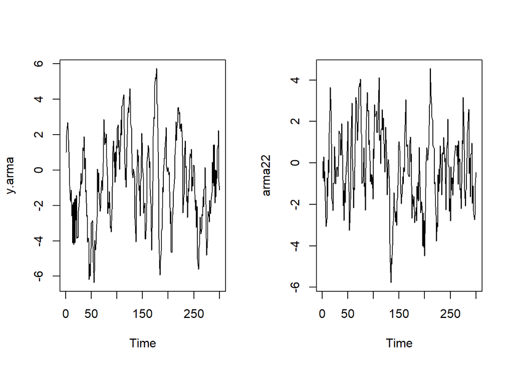

```r
par(mfrow = c(1, 2))
ts.plot(y.arma)
ts.plot(arma22)
```

```r
par(mfrow = c(1, 1))
```

Berdasarkan plot time series tersebut, terlihat bahwa model ARMA(2,2) cenderung stasioner dalam rataan

### Plot ACF

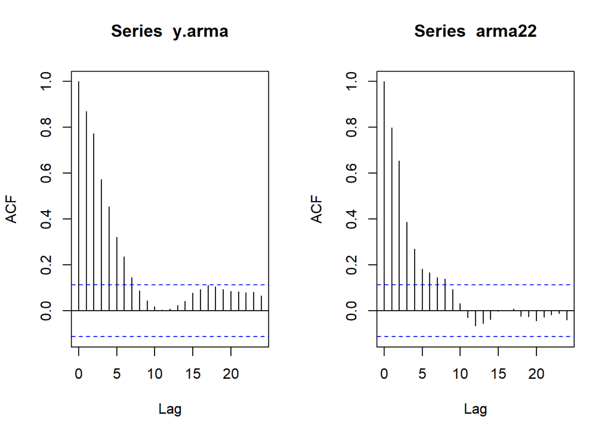

```r
par(mfrow = c(1, 2))
acf(y.arma)
acf(arma22)
```

```r
par(mfrow = c(1, 1))
```

### Plot PACF

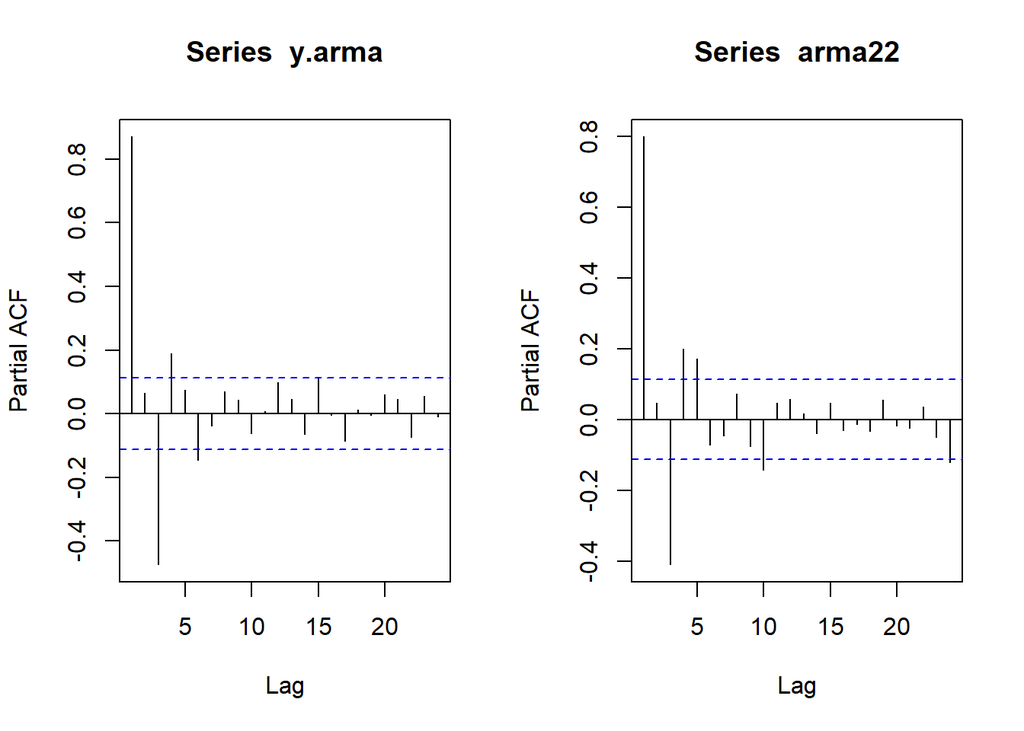

```r
par(mfrow = c(1, 2))
pacf(y.arma)
pacf(arma22)
```

```r
par(mfrow = c(1, 1))
```

### Plot EACF

```r
TSA::eacf(y.arma)
```

```
## AR/MA
##   0 1 2 3 4 5 6 7 8 9 10 11 12 13
## 0 x x x x x x x o o o o  o  o  o
## 1 o x x x o x o o o o o  o  o  o
## 2 x x x x o x o o o o o  o  o  o
## 3 x x x x o x o o o o o  o  o  o
## 4 x x x x x x o o o o o  o  o  o
## 5 x x x o o o o o o o o  o  o  o
## 6 x x x o o o o o o o o  o  o  o
## 7 x x x o o o o o o o o  o  o  o
```

```r
TSA::eacf(arma22)
```

```
## AR/MA
##   0 1 2 3 4 5 6 7 8 9 10 11 12 13
## 0 x x x x x x x x o o o  o  o  o
## 1 o x x o x o o o o o o  o  o  o
## 2 o x o o x o o o o o o  o  o  o
## 3 x x o x x o o o o o o  o  o  o
## 4 x x o x x o o o o o o  o  o  o
## 5 x x x o x o o o o o o  o  o  o
## 6 x x o o x x o o o o o  o  o  o
## 7 x o o x o x o x o o o  o  o  o
```

Berdasarkan pola segitiga nol pada plot EACF, terlihat bahwa segitiga nol berada pada ordo AR(1) dan ordo MA(5)

Dapat disimpulkan bahwa data tersebut stasioner

## Buat scatterplot dan korelasi antara $Y_t$ dengan $Y_{t-1}$, $Y_t$ dengan $Y_{t-2}$, serta $Y_t$ dengan $Y_{t-3}$

### Korelasi antara $Y_t$ dengan $Y_{t-1}$

```r
#Yt
yt_arma <- arma22[-1]
yt_arma
```

```
##   [1] -0.73270762  0.29534872 -0.88177243 -0.40494262 -1.81814223 -2.63974439
##   [7] -3.07358274 -2.71804095 -0.71635658 -1.61516276  0.15764457 -0.47266329
##  [13]  1.44725419  2.51482053  3.64981261  2.51808704  0.94646378 -1.73007867
##  [19] -1.96463282 -2.29104663 -0.97842919 -0.98485685  0.78966693  0.32630064
##  [25] -1.01519362 -0.68344715 -0.24220047 -0.19974042 -0.31979622 -0.65860929
##  [31]  0.35018410  1.55062920  1.41188175  1.42666841  0.38973575  0.37200962
##  [37]  1.89051914  0.67059914  0.39926045 -2.05092604 -1.31421244 -2.78184816
##  [43] -0.96490651 -1.90637179 -1.01510832 -0.16831790  0.05284366  1.04785331
##  [49]  1.99941115 -0.43399489 -1.38465073 -3.25854344 -2.91053917 -1.76146875
##  [55]  0.77132686  1.66259968  2.88184263  0.21059943 -0.37362893 -2.17441288
##  [61] -1.19599837 -1.30894285  0.91325166  1.90309705  3.17119697  2.87791790
##  [67]  2.00341061  1.09212683  1.91294317  2.58804162  3.64831854  3.84743593
##  [73]  3.69994307  4.04401256  1.44729195  1.38058144 -0.99201821 -0.89626703
##  [79] -0.67820990  0.73087800 -1.14706567 -0.95979023 -2.28773374 -0.24989283
##  [85]  1.59612400  2.88040043  3.40185649  2.50481229  2.54370604  0.89249915
```

[output cut: 35 more lines]

```r
#Yt-1
yt_1_arma <- arma22[-300]
yt_1_arma
```

```
##   [1]  0.06795477 -0.73270762  0.29534872 -0.88177243 -0.40494262 -1.81814223
##   [7] -2.63974439 -3.07358274 -2.71804095 -0.71635658 -1.61516276  0.15764457
##  [13] -0.47266329  1.44725419  2.51482053  3.64981261  2.51808704  0.94646378
##  [19] -1.73007867 -1.96463282 -2.29104663 -0.97842919 -0.98485685  0.78966693
##  [25]  0.32630064 -1.01519362 -0.68344715 -0.24220047 -0.19974042 -0.31979622
##  [31] -0.65860929  0.35018410  1.55062920  1.41188175  1.42666841  0.38973575
##  [37]  0.37200962  1.89051914  0.67059914  0.39926045 -2.05092604 -1.31421244
##  [43] -2.78184816 -0.96490651 -1.90637179 -1.01510832 -0.16831790  0.05284366
##  [49]  1.04785331  1.99941115 -0.43399489 -1.38465073 -3.25854344 -2.91053917
##  [55] -1.76146875  0.77132686  1.66259968  2.88184263  0.21059943 -0.37362893
##  [61] -2.17441288 -1.19599837 -1.30894285  0.91325166  1.90309705  3.17119697
##  [67]  2.87791790  2.00341061  1.09212683  1.91294317  2.58804162  3.64831854
##  [73]  3.84743593  3.69994307  4.04401256  1.44729195  1.38058144 -0.99201821
##  [79] -0.89626703 -0.67820990  0.73087800 -1.14706567 -0.95979023 -2.28773374
##  [85] -0.24989283  1.59612400  2.88040043  3.40185649  2.50481229  2.54370604
```

[output cut: 35 more lines]

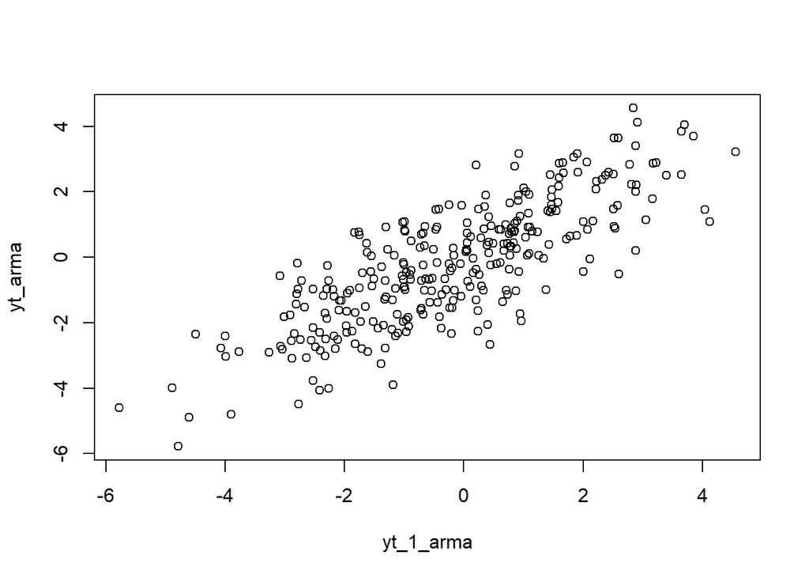

```r
plot(y=yt_arma,x=yt_1_arma)
```

Berdasarkan scatterplot tersebut, terlihat bahwa terdapat hubungan positif antara $Y_t$ dengan $Y_{t-1}$. Hal ini sesuai dengan teori yang ada

```r
cor(yt_arma,yt_1_arma)
```

```
## [1] 0.7981987
```

### Korelasi antara $Y_t$ dengan $Y_{t-2}$

```r
#Yt
yt_arma2 <- arma22[-c(1,2)]
yt_arma2
```

```
##   [1]  0.29534872 -0.88177243 -0.40494262 -1.81814223 -2.63974439 -3.07358274
##   [7] -2.71804095 -0.71635658 -1.61516276  0.15764457 -0.47266329  1.44725419
##  [13]  2.51482053  3.64981261  2.51808704  0.94646378 -1.73007867 -1.96463282
##  [19] -2.29104663 -0.97842919 -0.98485685  0.78966693  0.32630064 -1.01519362
##  [25] -0.68344715 -0.24220047 -0.19974042 -0.31979622 -0.65860929  0.35018410
##  [31]  1.55062920  1.41188175  1.42666841  0.38973575  0.37200962  1.89051914
##  [37]  0.67059914  0.39926045 -2.05092604 -1.31421244 -2.78184816 -0.96490651
##  [43] -1.90637179 -1.01510832 -0.16831790  0.05284366  1.04785331  1.99941115
##  [49] -0.43399489 -1.38465073 -3.25854344 -2.91053917 -1.76146875  0.77132686
##  [55]  1.66259968  2.88184263  0.21059943 -0.37362893 -2.17441288 -1.19599837
##  [61] -1.30894285  0.91325166  1.90309705  3.17119697  2.87791790  2.00341061
##  [67]  1.09212683  1.91294317  2.58804162  3.64831854  3.84743593  3.69994307
##  [73]  4.04401256  1.44729195  1.38058144 -0.99201821 -0.89626703 -0.67820990
##  [79]  0.73087800 -1.14706567 -0.95979023 -2.28773374 -0.24989283  1.59612400
##  [85]  2.88040043  3.40185649  2.50481229  2.54370604  0.89249915  1.09894149
```

[output cut: 35 more lines]

```r
#Yt-2
yt_2_arma <- arma22[-c(299,300)]
yt_2_arma
```

```
##   [1]  0.06795477 -0.73270762  0.29534872 -0.88177243 -0.40494262 -1.81814223
##   [7] -2.63974439 -3.07358274 -2.71804095 -0.71635658 -1.61516276  0.15764457
##  [13] -0.47266329  1.44725419  2.51482053  3.64981261  2.51808704  0.94646378
##  [19] -1.73007867 -1.96463282 -2.29104663 -0.97842919 -0.98485685  0.78966693
##  [25]  0.32630064 -1.01519362 -0.68344715 -0.24220047 -0.19974042 -0.31979622
##  [31] -0.65860929  0.35018410  1.55062920  1.41188175  1.42666841  0.38973575
##  [37]  0.37200962  1.89051914  0.67059914  0.39926045 -2.05092604 -1.31421244
##  [43] -2.78184816 -0.96490651 -1.90637179 -1.01510832 -0.16831790  0.05284366
##  [49]  1.04785331  1.99941115 -0.43399489 -1.38465073 -3.25854344 -2.91053917
##  [55] -1.76146875  0.77132686  1.66259968  2.88184263  0.21059943 -0.37362893
##  [61] -2.17441288 -1.19599837 -1.30894285  0.91325166  1.90309705  3.17119697
##  [67]  2.87791790  2.00341061  1.09212683  1.91294317  2.58804162  3.64831854
##  [73]  3.84743593  3.69994307  4.04401256  1.44729195  1.38058144 -0.99201821
##  [79] -0.89626703 -0.67820990  0.73087800 -1.14706567 -0.95979023 -2.28773374
##  [85] -0.24989283  1.59612400  2.88040043  3.40185649  2.50481229  2.54370604
```

[output cut: 35 more lines]

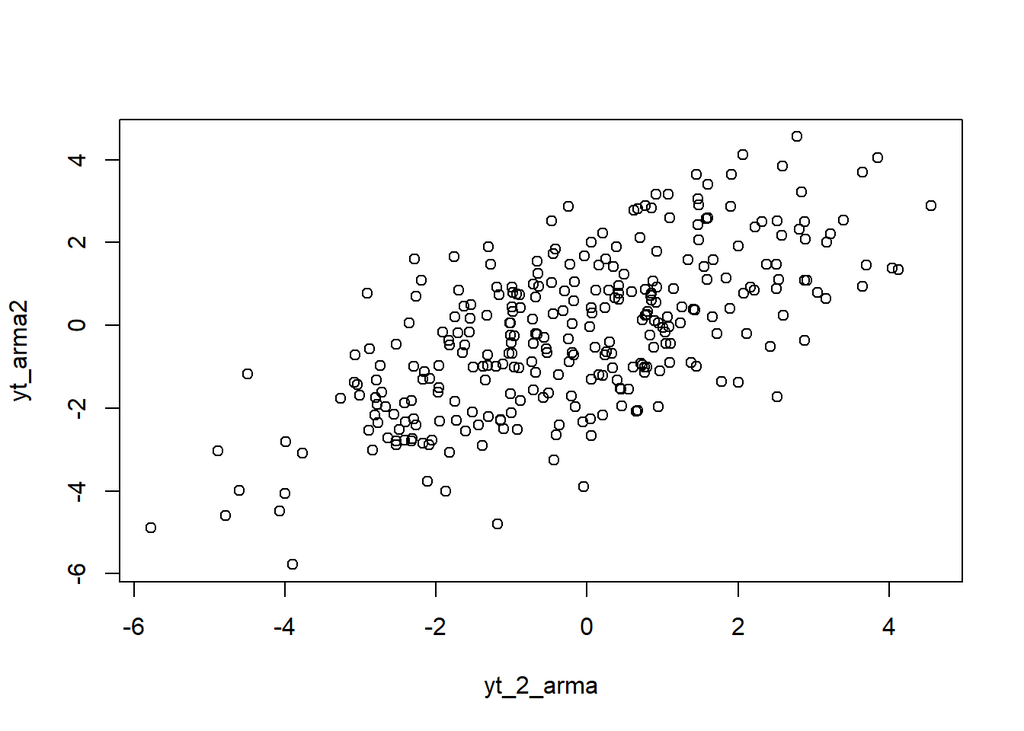

```r
plot(y=yt_arma2,x=yt_2_arma)
```

```r
cor(yt_arma2,yt_2_arma)
```

```
## [1] 0.6546106
```

### Korelasi antara $Y_t$ dengan $Y_{t-3}$

```r
#Yt
yt_arma3 <- arma22[-c(1,2,3)]
yt_arma3
```

```
##   [1] -0.88177243 -0.40494262 -1.81814223 -2.63974439 -3.07358274 -2.71804095
##   [7] -0.71635658 -1.61516276  0.15764457 -0.47266329  1.44725419  2.51482053
##  [13]  3.64981261  2.51808704  0.94646378 -1.73007867 -1.96463282 -2.29104663
##  [19] -0.97842919 -0.98485685  0.78966693  0.32630064 -1.01519362 -0.68344715
##  [25] -0.24220047 -0.19974042 -0.31979622 -0.65860929  0.35018410  1.55062920
##  [31]  1.41188175  1.42666841  0.38973575  0.37200962  1.89051914  0.67059914
##  [37]  0.39926045 -2.05092604 -1.31421244 -2.78184816 -0.96490651 -1.90637179
##  [43] -1.01510832 -0.16831790  0.05284366  1.04785331  1.99941115 -0.43399489
##  [49] -1.38465073 -3.25854344 -2.91053917 -1.76146875  0.77132686  1.66259968
##  [55]  2.88184263  0.21059943 -0.37362893 -2.17441288 -1.19599837 -1.30894285
##  [61]  0.91325166  1.90309705  3.17119697  2.87791790  2.00341061  1.09212683
##  [67]  1.91294317  2.58804162  3.64831854  3.84743593  3.69994307  4.04401256
##  [73]  1.44729195  1.38058144 -0.99201821 -0.89626703 -0.67820990  0.73087800
##  [79] -1.14706567 -0.95979023 -2.28773374 -0.24989283  1.59612400  2.88040043
##  [85]  3.40185649  2.50481229  2.54370604  0.89249915  1.09894149  0.10822216
```

[output cut: 35 more lines]

```r
#Yt-3
yt_3_arma <- arma22[-c(288,289,300)]
yt_3_arma
```

```
##   [1]  0.06795477 -0.73270762  0.29534872 -0.88177243 -0.40494262 -1.81814223
##   [7] -2.63974439 -3.07358274 -2.71804095 -0.71635658 -1.61516276  0.15764457
##  [13] -0.47266329  1.44725419  2.51482053  3.64981261  2.51808704  0.94646378
##  [19] -1.73007867 -1.96463282 -2.29104663 -0.97842919 -0.98485685  0.78966693
##  [25]  0.32630064 -1.01519362 -0.68344715 -0.24220047 -0.19974042 -0.31979622
##  [31] -0.65860929  0.35018410  1.55062920  1.41188175  1.42666841  0.38973575
##  [37]  0.37200962  1.89051914  0.67059914  0.39926045 -2.05092604 -1.31421244
##  [43] -2.78184816 -0.96490651 -1.90637179 -1.01510832 -0.16831790  0.05284366
##  [49]  1.04785331  1.99941115 -0.43399489 -1.38465073 -3.25854344 -2.91053917
##  [55] -1.76146875  0.77132686  1.66259968  2.88184263  0.21059943 -0.37362893
##  [61] -2.17441288 -1.19599837 -1.30894285  0.91325166  1.90309705  3.17119697
##  [67]  2.87791790  2.00341061  1.09212683  1.91294317  2.58804162  3.64831854
##  [73]  3.84743593  3.69994307  4.04401256  1.44729195  1.38058144 -0.99201821
##  [79] -0.89626703 -0.67820990  0.73087800 -1.14706567 -0.95979023 -2.28773374
##  [85] -0.24989283  1.59612400  2.88040043  3.40185649  2.50481229  2.54370604
```

[output cut: 35 more lines]

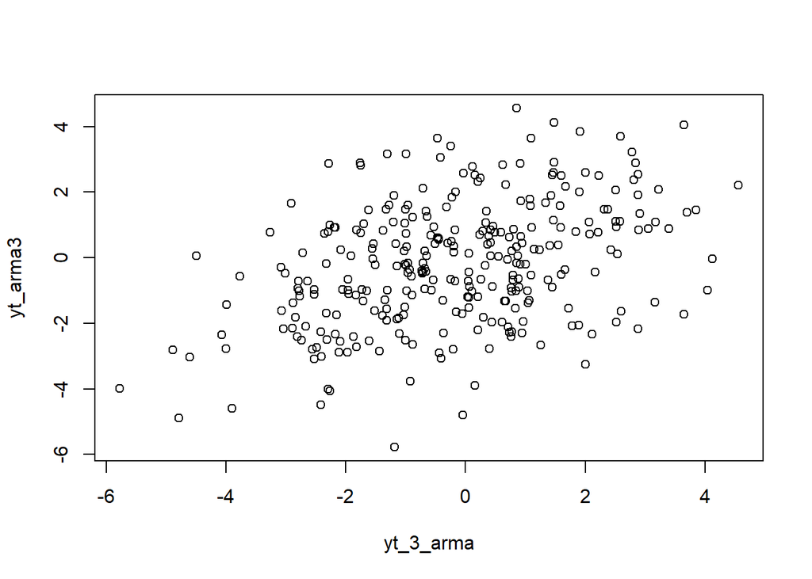

```r
plot(y=yt_arma3,x=yt_3_arma)
```

```r
cor(yt_arma3,yt_3_arma)
```

```
## [1] 0.4003797
```